# Python Programming - Lab - 14

```
Python Programming - 2301CS404
Lab - 14
Roll No : 496
Name : Dhruv Limbasiya
Enrollment : 24031701027
```

## Import matplotlib below

```python
import matplotlib.pyplot as plt
```

### 01) WAP to display the line chart for given data for x and y axis.

```python
x = range(1,11)
y = [1,5,9,7,5,6,3,2,4,9]
```

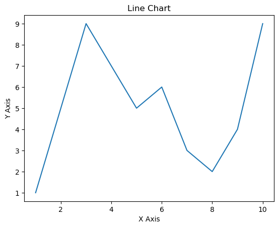

```python
plt.plot(x, y)
plt.title("Line Chart")
plt.xlabel("X Axis")
plt.ylabel("Y Axis")
plt.show()
```

### 02) WAP to generate line chart for given data.

```python
x = range(1,11,1)
cxMarks= [8,9,6,3,5,7,4,1,2,6]
cyMarks= [5,8,9,6,3,2,4,8,8,9]
```

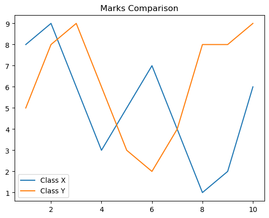

```python
plt.plot(x, cxMarks, label="Class X")
plt.plot(x, cyMarks, label="Class Y")

plt.legend()
plt.title("Marks Comparison")
plt.show()
```

### 03) WAP to generate line chart for given data, but create your custom axis.

```python
x = range(1,11)
y = [1,5,9,7,5,6,3,2,4,9]
```

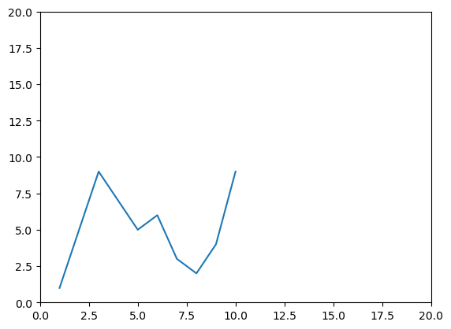

```python
ax = plt.axes()
ax.set_xlim([0,20])
ax.set_ylim([0,20])
plt.plot(x,y)
plt.show()
```

### 04) WAP to plot a line chart showing temperature variation during a week. Mark the lowest and highest temperatue.

```python
Days = ["Mon", "Tue", "Wed", "Thu", "Fri", "Sat", "Sun"]
Temperature = [20, 32, 31, 33, 34, 43, 36]
```

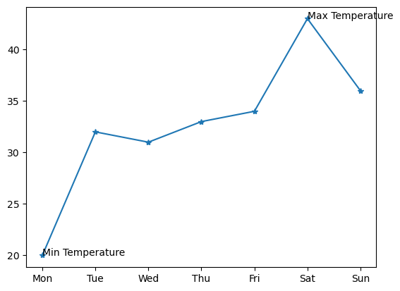

```python
plt.plot(Days , Temperature , marker="*")
plt.annotate("Max Temperature" , xy=(Days[Temperature.index(max(Temperature))],max(Temperature)))
plt.annotate("Min Temperature" , xy=(Days[Temperature.index(min(Temperature))],min(Temperature)))
plt.show()
```

### 05) WAP to create a detailed pie chart representing the monthly expenditure distribution of a family.

### The chart should display labels, percentage values, title, different colors for each slice, and explode one slice to highlight the highest expense.

```python
Categories = ["Rent", "Food", "Education", "Transport", "Entertainment", "Savings"]
Amount= [15000, 8000, 6000, 3000, 2000, 5000]
```

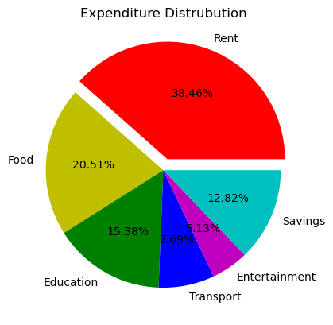

```python
color = ["r","y","g","b","m","c"]
plt.pie(Amount , labels=Categories , colors = color ,autopct = "%1.2f%%", explode=[0.1,0,0,0,0,0])
plt.title("Expenditure Distrubution")
plt.show()
```

### 06) WAP to create bar chart showing the marks obtained by students in different subjects.

### The program should also display the marks on the top of the respective bar.

```python
Subjects = ["Python", "DBMS", "SE", "PS", "PE-1"]
Marks = [78, 85, 72, 80, 90]
```

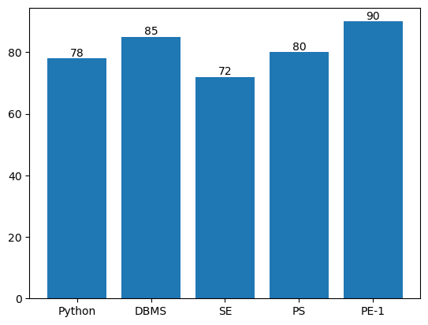

```python
bars = plt.bar(Subjects , Marks )
plt.bar_label(bars)
plt.show()
```

### 07) WAP to create a horizontal bar chart representing the number of books sold in different categories.

### The program should also display the number of books sold at the end of the respective bar.

```python
Categories = ["Fiction", "Science", "History", "Technology", "Biography"]
Books_Sold= [120, 90, 70, 110, 60]
```

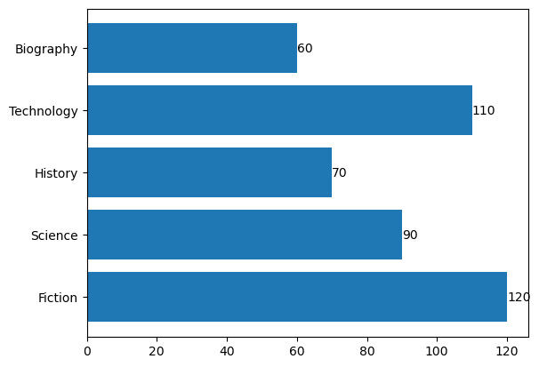

```python
bars = plt.barh(Categories ,  Books_Sold)
plt.bar_label(bars)
plt.show()
```

### 08) WAP to create a scatter plot representing the relationship between advertising expenditure and sales revenue of a company.

```python
Advertising_Cost = [5, 8, 10, 12, 15, 18, 20]
Sales_Revenue= [50, 60, 65, 70, 80, 90, 95]
```

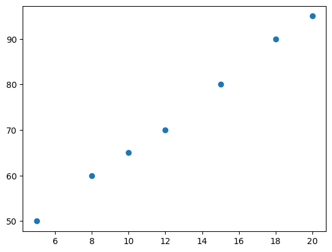

```python
plt.scatter(Advertising_Cost , Sales_Revenue )
plt.show()
```

### 09) WAP to create a histogram representing the distribution of marks obtained by students in a class.

```python
Marks = [45, 50, 55, 60, 62, 65, 68, 70, 72, 75, 78, 80, 82, 85, 88, 90, 92, 95]
```

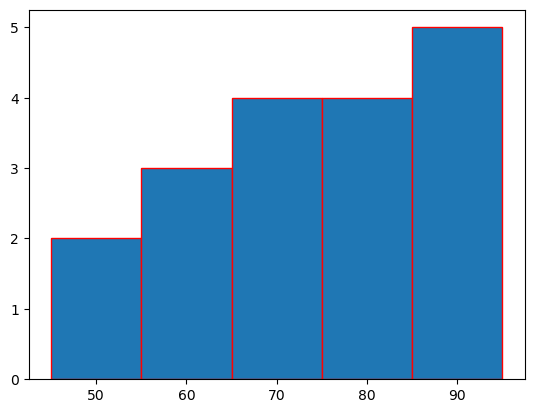

```python
plt.hist(Marks , bins = 5 , edgecolor ="r")
plt.show()
```

### 10) WAP to create a box plot representing the distribution of daily commuting time (in minutes) of employees and identify outliers (if any).

```python
Commuting_Time= [5, 18, 20, 22, 25, 27, 28, 30, 32, 35, 38, 40, 42, 90]
```

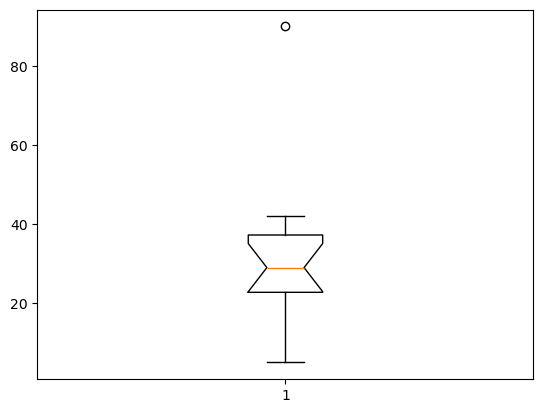

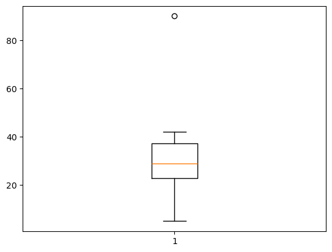

```python
plt.boxplot(Commuting_Time,notch=True)
plt.show()
plt.boxplot(Commuting_Time,notch=False)
plt.show()
```